# 01 — Cleaning and integration (Deliverable A)

Cleans the trip, weather, events and test files with one set of shared functions, joins them on one clock, builds the features, and exports the A8 tables to `data/processed/`.

| ID | Where in this notebook |
| --- | --- |
| A1 Cleaning log | Step 12 (re-saved with test rows in Step 22) |
| A2 Time & key standardization | Steps 4–6 (trips), 10–11 (weather, events), Step 13 (summary for all tables) |
| A3 Join map | Step 14 |
| A4 Join audit | Step 16 |
| A5 Join proof | Step 17 |
| A6 Feature table | Step 18 |
| A7 Integrity checks | Steps 8, 10, 11, 19, 20, 22 (PASS/FAIL output) |
| A8 Master tables + data dictionary | Steps 19 and 22 → `master_train.csv`, `master_test.csv`, `data_dictionary_master.csv` |

### Step 1 — Imports, paths and settings

```
C:\Users\hp\Desktop\qiyas-hack
```

### Step 2 — Common functions used by all three tables

### Step 3 — Load and profile the ride demand data

```
(85460, 7)
```

|  | nulls | null_pct | n_unique | min | max |
| --- | --- | --- | --- | --- | --- |
| record_id | 0 | 0.00 | 85460 | NaN | NaN |
| zone | 0 | 0.00 | 55 | NaN | NaN |
| pickup_hour | 0 | 0.00 | 20550 | NaN | NaN |
| trips | 845 | 0.99 | 231 | -1.0 | 640.0 |
| avg_fare_birr | 1277 | 1.49 | 1637 | 195.3 | 371.6 |
| avg_wait_min | 0 | 0.00 | 59 | -1.0 | 7.0 |
| active_drivers | 0 | 0.00 | 142 | 2.0 | 208.0 |

### Step 4 — A2(a) Standardise zone names (trips)

```
before: 55 labels
```

```
after: 12 labels -> ['Arat Kilo', 'Ayat', 'Bole', 'CMC', 'Gerji', 'Kazanchis', 'Kolfe', 'Lideta', 'Megenagna', 'Merkato', 'Piassa', 'Sarbet']
          raw_value clean_value  rows
0       'ARAT KILO'   Arat Kilo   677
1      'Arat  Kilo'   Arat Kilo   705
2      'Arat Kilo '   Arat Kilo   655
3       'Arat Kilo'   Arat Kilo  4506
4       'arat kilo'   Arat Kilo   729
5            'AYAT'        Ayat   675
6           'Ayat '        Ayat   721
7            'Ayat'        Ayat  3382
8            'ayat'        Ayat   729
9            'BOLE'        Bole   674
10          'Bole '        Bole   710
11        'Bole Rd'        Bole   689
12           'Bole'        Bole  4507
```

[output cut: 42 more lines]

### Step 5 — A2(b) Detect and parse timestamp formats (trips)

| pickup_hour | rows | pct | format | source_clock | example |
| --- | --- | --- | --- | --- | --- |
| 9999-99-99 99:99 | 46886 | 54.86 | %Y-%m-%d %H:%M | Africa/Addis_Ababa | 2025-06-26 11:00 |
| 99/99/9999 99:99 | 25764 | 30.15 | %d/%m/%Y %H:%M | Africa/Addis_Ababa | 16/08/2025 04:00 |
| 9999-99-99T99:99:99+99:99 | 12810 | 14.99 | %Y-%m-%dT%H:%M:%S%z | offset in string | 2025-05-27T23:00:00+03:00 |

```
slash field 1: 1 - 31 | field 2: 1 - 10
```

```
day-first    matches with ISO twin: 351
month-first  matches with ISO twin: 27
```

### Step 6 — A2(c) Check all timestamps are on the same clock (trips)

```
offsets present: {'+03:00': 12810}
fmt   99/99/9999 99:99  9999-99-99 99:99  9999-99-99T99:99:99+99:99
hour
0                  8.7               8.2                        9.2
1                  6.3               7.0                        6.7
2                  5.7               5.8                        5.7
3                  5.8               5.9                        6.4
4                  8.3               8.1                        8.2
5                 15.5              15.3                       14.6
6                 28.9              28.4                       28.5
7                 42.9              43.3                       42.7
8                 43.5              45.4                       43.2
9                 34.9              35.0                       36.3
10                29.6              30.3                       30.3
11                31.1              31.4                       30.9
12                35.7              34.5                       35.5
13                38.8              37.9                       35.7
14                37.1              35.8                       36.5
15                34.0              34.4                       35.7
16                39.2              40.0                       39.1
17                49.1              48.7                       49.0
18                53.5              53.3                       52.5
19                47.7              48.4                       50.3
20                38.4              37.2                       38.8
21                26.9              26.6                       25.7
22                18.5              17.4                       18.0
23                11.8              11.4                       12.3
corr(naive shifted -3h, +03:00) = 0.253
corr(naive shifted +0h, +03:00) = 0.998
corr(naive shifted +3h, +03:00) = 0.291
```

### Step 7 — Clean the ride demand data

```
(85460, 7) -> (82742, 9)
```

|  | record_id | zone | pickup_hour | trips | avg_fare_birr | avg_wait_min | active_drivers | fare_imputed | wait_imputed |
| --- | --- | --- | --- | --- | --- | --- | --- | --- | --- |
| 0 | R-070502 | Arat Kilo | 2025-01-01 | 5 | 240.4 | 1.9 | 5 | 0 | 0 |
| 1 | R-058374 | Bole | 2025-01-01 | 8 | 322.8 | 3.0 | 6 | 0 | 0 |
| 2 | R-073684 | CMC | 2025-01-01 | 4 | 289.2 | 1.6 | 5 | 0 | 0 |
| 3 | R-016735 | Gerji | 2025-01-01 | 2 | 290.2 | 1.5 | 3 | 0 | 0 |
| 4 | R-002178 | Kazanchis | 2025-01-01 | 0 | 248.5 | 1.2 | 2 | 0 | 0 |

### Step 8 — A7 Integrity checks: cleaned trips

```
--- trips
PASS  one row per zone-hour
PASS  record_id unique
PASS  only the 12 canonical zones
PASS  timestamps naive EAT, on the hour
PASS  timestamps in 2025-01-01 .. 2025-10-31
PASS  no missing values
PASS  no negative / sentinel values
PASS  trips/driver <= 3 (no x8 inflation)
PASS  trips is a non-negative integer
PASS  rows reconcile: raw - dropped = clean
```

```
conflicting zone-hours: 362 (724 rows)
trip difference: {1.0: 122, 2.0: 125, 3.0: 115}
by zone: {'Merkato': 40, 'Bole': 38, 'Kazanchis': 35, 'Kolfe': 34, 'Piassa': 30, 'Megenagna': 29, 'Arat Kilo': 28, 'Gerji': 28, 'CMC': 27, 'Sarbet': 26, 'Lideta': 24, 'Ayat': 23}
by hour: {0: 18, 1: 14, 2: 13, 3: 16, 4: 17, 5: 13, 6: 13, 7: 15, 8: 14, 9: 13, 10: 10, 11: 23, 12: 16, 13: 18, 14: 18, 15: 15, 16: 18, 17: 14, 18: 12, 19: 11, 20: 13, 21: 15, 22: 12, 23: 21}
```

### Step 9 — Save the cleaned trips (`trips_clean.csv`)

```
saved trips_clean.csv (82742, 9)
```

### Step 10 — Clean the weather data

```
(7538, 6) -> (7656, 8)
```

```
--- weather
PASS  one row per hour
PASS  continuous hourly index
PASS  covers trip range with 3h lookback
PASS  no missing values
PASS  temp_c in 0-40
PASS  humidity_pct in 0-100
PASS  rain_mm >= 0
```

### Step 11 — Clean the events data

```
                       rows    pct              format        source_clock
start_datetime
9999-99-99 99:99         79  47.88      %Y-%m-%d %H:%M  Africa/Addis_Ababa
99/99/9999 99:99         50  30.30      %d/%m/%Y %H:%M  Africa/Addis_Ababa
Mon 99, 9999 99:99 PM    21  12.73  %b %d, %Y %I:%M %p  Africa/Addis_Ababa
Mon 99, 9999 99:99 AM    15   9.09  %b %d, %Y %I:%M %p  Africa/Addis_Ababa
```

```
slash field 1: 1 - 31 | field 2: 1 - 11

event_type before -> after:
            raw_value     clean_value  rows
0           'CONCERT'         concert    14
1           'Concert'         concert     6
2           'concert'         concert     8
3        'Conference'      conference    19
4        'conference'      conference    19
5        'Exhibition'      exhibition     3
6        'exhibition'      exhibition     4
7    'Football Match'  football_match    15
8   'football match '  football_match    14
9    'football_match'  football_match    22
10   'Public Holiday'  public_holiday     5
11   'public holiday'  public_holiday     2
12   'public_holiday'  public_holiday     6
13     'Road closure'    road_closure     3
14     'road closure'    road_closure    11
15     'road_closure'    road_closure     9
16     'School Break'    school_break     1
17     'school_break'    school_break     1
18       'Sports Run'      sports_run     1
19       'sports_run'      sports_run     2

165 raw rows -> 159 unique events (6 cancelled) -> 328 event-zone rows
```

|  | event_id | event_name | event_type | venue | zone | is_citywide | is_multi_zone | start_datetime | end_datetime | end_imputed | end_rounded | expected_attendance | attendance_imputed | status | is_cancelled |
| --- | --- | --- | --- | --- | --- | --- | --- | --- | --- | --- | --- | --- | --- | --- | --- |
| 0 | EVT-0001 | Genna (Ethiopian Christmas) | public_holiday | none | Arat Kilo | 1 | 0 | 2025-01-07 | 2025-01-08 | 0 | 1 | 0 | 0 | confirmed | 0 |
| 1 | EVT-0001 | Genna (Ethiopian Christmas) | public_holiday | none | Ayat | 1 | 0 | 2025-01-07 | 2025-01-08 | 0 | 1 | 0 | 0 | confirmed | 0 |
| 2 | EVT-0001 | Genna (Ethiopian Christmas) | public_holiday | none | Bole | 1 | 0 | 2025-01-07 | 2025-01-08 | 0 | 1 | 0 | 0 | confirmed | 0 |
| 3 | EVT-0001 | Genna (Ethiopian Christmas) | public_holiday | none | CMC | 1 | 0 | 2025-01-07 | 2025-01-08 | 0 | 1 | 0 | 0 | confirmed | 0 |
| 4 | EVT-0001 | Genna (Ethiopian Christmas) | public_holiday | none | Gerji | 1 | 0 | 2025-01-07 | 2025-01-08 | 0 | 1 | 0 | 0 | confirmed | 0 |

```
--- events
PASS  one row per event and zone
PASS  only the 12 canonical zones
PASS  only the 8 event types
PASS  status is confirmed or cancelled
PASS  no missing values
PASS  end after start
PASS  start and end on the hour
PASS  attendance is a non-negative integer
PASS  citywide events cover all 12 zones
saved events_clean.csv (328, 15)
```

### Step 12 — A1 Cleaning log

|  | file | column(s) | issue_type | rows_affected | pct_rows | fix_applied | why |
| --- | --- | --- | --- | --- | --- | --- | --- |
| 1 | ride_demand_train.csv | zone | Inconsistent case / extra whitespace | 27533 | 32.22 | trim, collapse spaces, case-insensitive match | Same zone would otherwise count as different g... |
| 2 | ride_demand_train.csv | zone | Aliases / misspellings (Piazza, Mercato, C.M.C... | 4858 | 5.68 | alias map to canonical label; unknown labels r... | All tables must share the same 12 zone keys |
| 3 | ride_demand_train.csv | pickup_hour | Mixed timestamp formats (DD/MM/YYYY, ISO with ... | 38574 | 45.14 | explicit format per pattern (day-first verified) | Guessing can swap day/month and break hourly j... |
| 4 | ride_demand_train.csv | pickup_hour | Mixed clocks: +03:00 offset vs naive | 12810 | 14.99 | convert to Africa/Addis_Ababa, drop tz | All tables must share one clock for the joins |
| 5 | ride_demand_train.csv | trips | Sentinel -1 | 681 | 0.80 | set to NaN (missing target) | -1 is a no-data code, not a count |
| 6 | ride_demand_train.csv | avg_wait_min | Sentinel -1 | 1707 | 2.00 | set to NaN, then imputed | A negative wait is impossible |
| 7 | ride_demand_train.csv | trips | Outlier: values inflated x8 (trips/driver >= 4) | 124 | 0.15 | divide by 8 where ratio > 3 and trips % 8 == 0 | Physically implausible; /8 restores the normal... |
| 8 | ride_demand_train.csv | trips | Outlier: implausible ratio, not a multiple of 8 | 1 | 0.00 | row dropped | True value unrecoverable |
| 9 | ride_demand_train.csv | zone, pickup_hour | Duplicate zone-hours with different trip counts | 724 | 0.85 | removed from train, saved to trip_conflicts.csv | No evidence which count is correct |
| 10 | ride_demand_train.csv | zone, pickup_hour | Duplicate zone-hours with the same or one miss... | 483 | 0.57 | keep 1 row per zone-hour (most complete, then ... | Double-counts demand; breaks many-to-one joins |
| 11 | ride_demand_train.csv | trips | Missing target (blank or -1) | 1510 | 1.77 | row dropped from train | Imputing the target invents labels |
| 12 | ride_demand_train.csv | avg_fare_birr | Missing values | 1277 | 1.49 | train median by zone x hour (+ fare_imputed flag) | Fare follows a zone/hour pattern |
| 13 | ride_demand_train.csv | avg_wait_min | Spike at 1.2 min (platform floor) - checked | 8967 | 10.49 | kept unchanged | Plausible minimum wait, mostly at night |
| 14 | weather_hourly.csv | timestamp | Mixed timestamp formats (ISO Z, DD/MM/YYYY) | 732 | 9.71 | explicit format per pattern (day-first verified) | Guessing can swap day/month and break hourly j... |
| 15 | weather_hourly.csv | timestamp | UTC clock (both Z and slash rows) | 7538 | 100.00 | convert UTC to Africa/Addis_Ababa (+3h), drop tz | All tables must share one clock for the joins |
| 16 | weather_hourly.csv | rain_mm | Sentinel -9999 | 76 | 1.01 | set to NaN, then filled | -9999 is a no-data code |
| 17 | weather_hourly.csv | temp_c | Unit error: Fahrenheit values (54-77) | 353 | 4.68 | (F - 32) * 5/9 where temp_c > 40 | Addis is never above 40 C; converted values fi... |
| 18 | weather_hourly.csv | timestamp | Duplicate hours (observed vs forecast / same h... | 75 | 0.99 | keep 1 row per hour: observed first, then most... | Weather join must be many-to-one |
| 19 | weather_hourly.csv | timestamp | Missing hours (no weather row) | 193 | 2.56 | added to a full hourly index, then filled below | Hidden gaps would make lag features use the wr... |
| 20 | weather_hourly.csv | temp_c | Missing values | 42 | 0.56 | interpolate gaps <= 3h, else train median by m... | Temperature/humidity change smoothly hour to hour |
| 21 | weather_hourly.csv | humidity_pct | Missing values | 153 | 2.03 | interpolate gaps <= 3h, else train median by m... | Temperature/humidity change smoothly hour to hour |
| 22 | events_calendar.csv | event_type | Inconsistent spellings (case, spaces, undersco... | 94 | 56.97 | lower-case, spaces -> '_', 8 types | One label per type for event features |
| 23 | events_calendar.csv | zone | Sub-city in brackets / case / aliases | 67 | 40.61 | normalize_zone (same map as trips) | All tables must share the same 12 zone keys |
| 24 | events_calendar.csv | zone | Several zones in one cell ('A & B') | 5 | 3.03 | expand_zones: one row per zone, event_id kept | The event affects each listed zone |
| 25 | events_calendar.csv | zone | Citywide labels (Citywide, ALL, All zones, cit... | 15 | 9.09 | expand_zones: one row for each of the 12 zones... | Citywide is not a 13th zone |
| 26 | events_calendar.csv | start_datetime, end_datetime | Mixed timestamp formats (ISO, DD/MM/YYYY, 'Mon... | 129 | 78.18 | parse_timestamps with explicit formats (day-fi... | Guessing can swap day/month and misplace event... |
| 27 | events_calendar.csv | end_datetime | End at 23:59 instead of a full hour | 15 | 9.09 | rounded up to the next full hour (exclusive end) | Event windows must cover whole zone-hours |
| 28 | events_calendar.csv | status | Inconsistent case / trailing spaces | 28 | 16.97 | trim + lower-case -> confirmed / cancelled | One label per status |
| 29 | events_calendar.csv | status | Cancelled events | 6 | 3.64 | kept in the file with is_cancelled=1; excluded... | A cancelled event draws no crowd |
| 30 | events_calendar.csv | event_id | Duplicate events re-issued with new IDs | 6 | 3.64 | dedupe on every column except event_id; origin... | The same event would be counted twice |
| 31 | events_calendar.csv | end_datetime | Missing end time | 4 | 2.42 | start + train median duration for the event ty... | The event window needs an end |
| 32 | events_calendar.csv | end_datetime | End before start | 1 | 0.61 | treated as missing and filled the same way (EV... | An event cannot end before it starts |
| 33 | events_calendar.csv | expected_attendance | Stored as text ('approx 34000', '2,039') | 23 | 13.94 | to_number: removed 'approx' and commas | Attendance must be numeric for features |
| 34 | events_calendar.csv | expected_attendance | Missing where attendance does not apply | 37 | 22.42 | set to 0 (holidays, road closures, school breaks) | These events have no ticketed crowd |
| 35 | events_calendar.csv | expected_attendance | Missing where attendance applies | 16 | 9.70 | train median for the event type (attendance_im... | Keeps the attendance feature usable |
| 36 | events_calendar.csv | venue | Missing venue (checked) | 37 | 22.42 | filled 'none' | Only missing for holidays, road closures, scho... |

### Step 13 — A2 Time & key standardization (summary for all three tables)

#### A2(a) Zone and event_type labels before and after

```
events zone: 28 raw labels -> 12 zones (+ 'ALL' and 'A|B', expanded to one row per zone)
                  raw_value          clean_value  rows
0                     'ALL'                  ALL     3
1               'All zones'                  ALL     2
2                'Citywide'                  ALL     9
3               'city-wide'                  ALL     1
4               'arat kilo'            Arat Kilo     1
5      'Arat Kilo & SARBET'     Arat Kilo|Sarbet     1
6                    'AYAT'                 Ayat     2
7                    'Ayat'                 Ayat     1
8           'Ayat & Lideta'          Ayat|Lideta     1
9                    'BOLE'                 Bole     5
10    'Bole (Bole subcity)'                 Bole    10
11                   'Bole'                 Bole    29
12                    'CMC'                  CMC     1
```

[output cut: 20 more lines]

#### A2(b) Timestamp formats parsed per table, and the day-first check

```
--- trips
```

```
                            rows    pct               format        source_clock
pickup_hour
9999-99-99 99:99           46886  54.86       %Y-%m-%d %H:%M  Africa/Addis_Ababa
99/99/9999 99:99           25764  30.15       %d/%m/%Y %H:%M  Africa/Addis_Ababa
9999-99-99T99:99:99+99:99  12810  14.99  %Y-%m-%dT%H:%M:%S%z    offset in string
--- weather
                      rows    pct              format source_clock
timestamp
9999-99-99T99:99:99Z  6806  90.29  %Y-%m-%dT%H:%M:%SZ          UTC
99/99/9999 99:99       732   9.71      %d/%m/%Y %H:%M          UTC
--- events start
                       rows    pct              format        source_clock
start_datetime
9999-99-99 99:99         79  47.88      %Y-%m-%d %H:%M  Africa/Addis_Ababa
99/99/9999 99:99         50  30.30      %d/%m/%Y %H:%M  Africa/Addis_Ababa
Mon 99, 9999 99:99 PM    21  12.73  %b %d, %Y %I:%M %p  Africa/Addis_Ababa
Mon 99, 9999 99:99 AM    15   9.09  %b %d, %Y %I:%M %p  Africa/Addis_Ababa
--- events end
                       rows    pct              format        source_clock
end_datetime
9999-99-99 99:99         81  50.31      %Y-%m-%d %H:%M  Africa/Addis_Ababa
99/99/9999 99:99         47  29.19      %d/%m/%Y %H:%M  Africa/Addis_Ababa
Mon 99, 9999 99:99 PM    27  16.77  %b %d, %Y %I:%M %p  Africa/Addis_Ababa
Mon 99, 9999 99:99 AM     6   3.73  %b %d, %Y %I:%M %p  Africa/Addis_Ababa

day-first check:
```

```
               rows  field1_max  field2_max  fail_if_month_first
trips         25764          31          10                15713
weather         732          31          12                  412
events start     50          31          11                   28
events end       47          31          11                   17
```

#### A2(c) Which clock each table is on

```
weather: slash rows vs Z series, median |temp diff| by shift (h): {-4: 3.6, -3: 2.7, -2: 1.8, -1: 1.0, 0: 0.55, 1: 1.1, 2: 1.8, 3: 2.6, 4: 3.3}
weather: mean temp peaks at 15 :00 Addis time after the +3h conversion
events: start hours by type (Addis time): {'concert': [np.int32(19), np.int32(20)], 'conference': [np.int32(8)], 'exhibition': [np.int32(10)], 'football_match': [np.int32(15), np.int32(18), np.int32(19)], 'public_holiday': [np.int32(0)], 'road_closure': [np.int32(2), np.int32(3), np.int32(5), np.int…
```

|  | table | raw clock | evidence | conversion applied |
| --- | --- | --- | --- | --- |
| 0 | trips | Addis local (EAT, UTC+3) | ISO rows carry +03:00; naive rows share the sa... | offset rows tz-converted to EAT; naive rows un... |
| 1 | weather | UTC (both 'Z' and DD/MM rows) | slash rows fit the Z series best at shift 0 (0... | all rows +3h to EAT, tz dropped |
| 2 | events | Addis local (EAT) | matches start 15/18/19h, concerts 19–20h, conf... | none (already local) |

### Step 14 — A3 Join map

| Join | Left table | Right table | Key | Join type | Cardinality |
| --- | --- | --- | --- | --- | --- |
| 1 | cleaned trips (one row per zone-hour) | cleaned weather (one row per hour) | `pickup_hour` = `timestamp` | left | many-to-one (12 zone-hours → 1 weather hour) |
| 2 | result of join 1 | event windows (one row per event × zone × hour) | `zone` + `pickup_hour` inside [start − 2h, end + 2h) | left, interval | many-to-many, aggregated to one row per zone-hour before joining |
| 3 | result of join 2 | public holidays / school breaks | `zone` + `pickup_hour` inside [start, end) | left, interval | many-to-one after de-duplication |

**Why trips is the left table:** a zone-hour is the unit we forecast, so every trip row must survive every join, and weather or events must never add or drop rows.

**Event window rule:** from **2 hours before the start** to **2 hours after the end**. fig08 shows demand rising from −2h (people travelling in) and a second peak just after the end (people leaving; matches last ~2h, concerts ~4h).

Holidays and school breaks are whole-day or multi-week calendar periods, so they become calendar flags, not event windows.

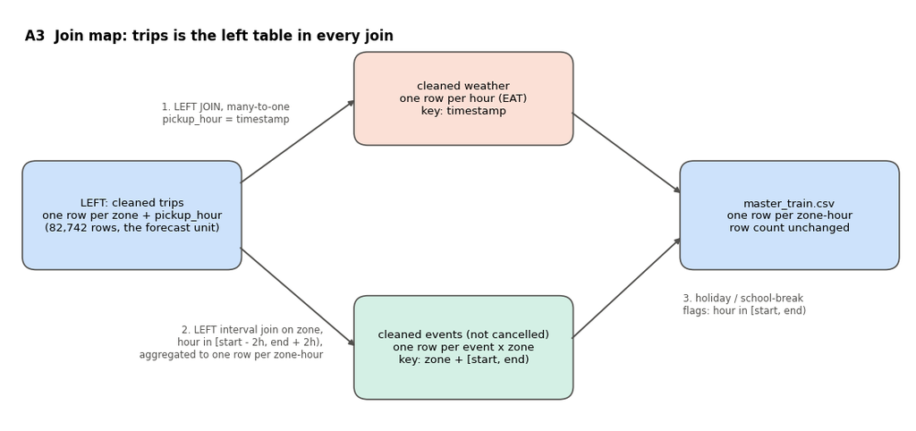

### Step 15 — Integrate: join weather and events, build features

```
rows: trips 82,742 -> +weather 82,742 -> +events 82,742 -> final 82,742
```

### Step 16 — A4 Join audit

```
                                                      join  rows_before  rows_after  matched_rows  match_rate_pct
                     trips ← weather (many-to-one on hour)        82742       82742         82742          100.00
trips ← event windows (interval, aggregated per zone-hour)        82742       82742          1829            2.21

zone-hours whose weather hour had NO original row: 2,154 (186 distinct hours) — station gaps in the raw file; filled in Step 10 (interpolation <= 3h, else month x hour median) and flagged weather_row_missing=1
zone-hours with any estimated weather value: 5,036
```

```
159 unique events:
                                                       events
matched >= 1 zone-hour                                    146
excluded: after the Jan–Oct trip period (test period)       7
excluded: cancelled                                         6
event_id
EVT-0020                                  excluded: cancelled
EVT-0042                                  excluded: cancelled
EVT-0052                                  excluded: cancelled
EVT-0058                                  excluded: cancelled
EVT-0099                                  excluded: cancelled
EVT-0113                                  excluded: cancelled
EVT-0153    excluded: after the Jan–Oct trip period (test ...
EVT-0154    excluded: after the Jan–Oct trip period (test ...
EVT-0155    excluded: after the Jan–Oct trip period (test ...
EVT-0156    excluded: after the Jan–Oct trip period (test ...
EVT-0157    excluded: after the Jan–Oct trip period (test ...
EVT-0158    excluded: after the Jan–Oct trip period (test ...
EVT-0159    excluded: after the Jan–Oct trip period (test ...
```

### Step 17 — A5 Join proof: three zone-hours

```
=== rain: Arat Kilo @ 2025-05-02 17:00:00
weather row attached:
          timestamp  temp_c  rain_mm  humidity_pct  wind_kmh  is_forecast  weather_row_missing  weather_imputed
2025-05-02 17:00:00    21.5     21.0          76.0       6.1            0                    0                0
event rows attached: none
features produced:
     zone         pickup_hour trips temp_c rain_mm rain_3h rain_class weather_imputed ev_in_window ev_attendance hours_to_next_event hours_since_event_end is_holiday is_weekend lag_14d
Arat Kilo 2025-05-02 17:00:00    96   21.5    21.0    21.8          3               0            0             0                48.0                  48.0          0          0    20.0

=== event window: Kazanchis @ 2025-01-19 15:00:00
weather row attached:
          timestamp  temp_c  rain_mm  humidity_pct  wind_kmh  is_forecast  weather_row_missing  weather_imputed
2025-01-19 15:00:00    23.7      0.0          56.0      14.0            0                    0                0
event rows attached:
event_id           event_name     event_type      start_datetime        end_datetime  expected_attendance
EVT-0003    Timkat (Epiphany) public_holiday 2025-01-19 00:00:00 2025-01-20 00:00:00                    0
EVT-0004 Premier league match football_match 2025-01-19 15:00:00 2025-01-19 17:00:00                16007
features produced:
     zone         pickup_hour trips temp_c rain_mm rain_3h rain_class weather_imputed ev_in_window ev_attendance hours_to_next_event hours_since_event_end is_holiday is_weekend lag_14d
Kazanchis 2025-01-19 15:00:00    13   23.7     0.0     0.0          0               0            1         16007                 0.0                  48.0          1          1    17.0

=== public holiday: Arat Kilo @ 2025-01-07 12:00:00
weather row attached:
          timestamp  temp_c  rain_mm  humidity_pct  wind_kmh  is_forecast  weather_row_missing  weather_imputed
2025-01-07 12:00:00    19.4      0.0          68.0      10.1            0                    0                0
event rows attached:
event_id                  event_name     event_type start_datetime end_datetime  expected_attendance
EVT-0001 Genna (Ethiopian Christmas) public_holiday     2025-01-07   2025-01-08                    0
features produced:
     zone         pickup_hour trips temp_c rain_mm rain_3h rain_class weather_imputed ev_in_window ev_attendance hours_to_next_event hours_since_event_end is_holiday is_weekend lag_14d
Arat Kilo 2025-01-07 12:00:00    14   19.4     0.0     0.0          0               0            0             0                48.0                  48.0          1          0     NaN
```

### Step 18 — A6 Feature engineering table

|  | feature | formula | source columns | why it should help | known at forecast time? |
| --- | --- | --- | --- | --- | --- |
| 0 | hour | pickup_hour.hour | pickup_hour | Strong daily demand cycle (peaks 08h / 18h) | yes |
| 1 | dow | pickup_hour.dayofweek (0=Mon) | pickup_hour | Weekday vs weekend patterns differ by zone type | yes |
| 2 | is_weekend | dow >= 5 | pickup_hour | Business zones drop ~50% at weekends, Bole rises | yes |
| 3 | month | pickup_hour.month | pickup_hour | Seasonality (rainy season Jun–Sep) | yes |
| 4 | days_to_month_end | days_in_month - day | pickup_hour | Payday proxy: spending rises near month end | yes |
| 5 | trend_days | days since 1 Jan 2025 | pickup_hour | Demand grew ~41% Jan→Oct | yes |
| 6 | is_holiday | zone-hour inside a public_holiday event | events.event_type, start/end | Holidays run at ~0.8x a weekday (fig09) | yes |
| 7 | is_school_break | zone-hour inside a school_break event | events.event_type, start/end | Commute pattern changes in school breaks | yes |
| 8 | temp_c | hourly temperature (°C, EAT) | weather.temp_c | Comfort affects walking vs riding | yes (weather forecast) |
| 9 | rain_mm | rain in the hour | weather.rain_mm | Rain raises demand ~1.6x (except Merkato, fig07) | yes (weather forecast) |
| 10 | rain_3h | sum of rain_mm over the last 3 hours | weather.rain_mm | Wet streets keep demand up after rain stops | yes (weather forecast) |
| 11 | rain_class | 0 dry, 1 <=1mm, 2 1–5mm, 3 >5mm | weather.rain_mm | Non-linear rain effect by intensity | yes (weather forecast) |
| 12 | humidity_pct / wind_kmh | hourly values | weather | Secondary weather signals | yes (weather forecast) |
| 13 | weather_imputed | 1 if any weather value was estimated | weather_clean flags | Lets the model trust estimated weather less | yes |
| 14 | ev_in_window | 1 if zone-hour in [start-2h, end+2h) of any event | events zone, start/end | Crowds before and after events (fig08) | yes (scheduled) |
| 15 | ev_attendance | sum of expected_attendance of events in window | events.expected_attendance | Bigger crowds, bigger spikes | yes (scheduled) |
| 16 | ev_<type> | 1 if a <type> event window covers the zone-hour | events.event_type | Matches, concerts, conferences peak at differe... | yes (scheduled) |
| 17 | hours_to_next_event | hours until next event start in the zone (cap 48) | events.start_datetime | Arrival build-up before start | yes (scheduled) |
| 18 | hours_since_event_end | hours since last event end in the zone (cap 48) | events.end_datetime | Exit surge after the end | yes (scheduled) |
| 19 | lag_14d / lag_21d / lag_28d | trips same zone & hour 14/21/28 days earlier | trips | Recent level of demand for that zone-hour | yes (horizon <= 14 days) |
| 20 | lag_mean_14_28d | mean of the three lags | trips | Smoother recent level, robust to one odd day | yes (horizon <= 14 days) |
| 21 | avg_fare_birr, avg_wait_min, active_drivers | observed in the same hour | trips | NOT used as features | no |

### Step 19 — A7 Integrity checks and A8 `master_train.csv`

```
--- integration
PASS  row count unchanged by every join
PASS  one row per zone-hour
PASS  every zone-hour matched a weather hour
PASS  only the 12 canonical zones
PASS  no missing values outside lag features
PASS  no cancelled event in any feature
PASS  weather columns complete
```

```
saved master_train.csv (82742, 40)
```

### Step 20 — Load and clean the test file (same rules as train)

```
(4032, 3)
```

|  | nulls | null_pct | n_unique | min | max |
| --- | --- | --- | --- | --- | --- |
| row_id | 0 | 0.0 | 4032 | NaN | NaN |
| zone | 0 | 0.0 | 55 | NaN | NaN |
| pickup_hour | 0 | 0.0 | 949 | NaN | NaN |

```
zones before: 55 -> after: ['Arat Kilo', 'Ayat', 'Bole', 'CMC', 'Gerji', 'Kazanchis', 'Kolfe', 'Lideta', 'Megenagna', 'Merkato', 'Piassa', 'Sarbet']
                           rows    pct               format        source_clock
pickup_hour
9999-99-99 99:99           2261  56.08       %Y-%m-%d %H:%M  Africa/Addis_Ababa
99/99/9999 99:99           1198  29.71       %d/%m/%Y %H:%M  Africa/Addis_Ababa
9999-99-99T99:99:99+99:99   573  14.21  %Y-%m-%dT%H:%M:%S%z    offset in string
```

```
day-first check: {'rows': 1198, 'field1_max': 14, 'field2_max': 11, 'fail_if_month_first': 167}; read month-first these rows would fall in [np.int64(1), np.int64(2), np.int64(3), np.int64(4), np.int64(5), np.int64(6), np.int64(7), np.int64(8), np.int64(9), np.int64(10), np.int64(11), np.int64(12)] i…
```

|  | row_id | zone | pickup_hour |
| --- | --- | --- | --- |
| 0 | TEST-00207 | Arat Kilo | 2025-11-01 |
| 1 | TEST-00254 | Ayat | 2025-11-01 |
| 2 | TEST-03783 | Bole | 2025-11-01 |
| 3 | TEST-02587 | CMC | 2025-11-01 |
| 4 | TEST-03249 | Gerji | 2025-11-01 |

```
--- test cleaning
PASS  no row dropped (row count = raw)
PASS  row_id unique
PASS  one row per zone-hour
PASS  only the 12 canonical zones
PASS  complete 12-zone x hourly grid
PASS  test period starts right after train
PASS  test period is 14 days (lags of 14+ days are all from train)
PASS  no missing values
```

### Step 21 — Build test features with exactly the same pipeline

Step 15 as a reusable function. It is first run on the train rows and must reproduce the train features exactly; then it is applied to the test rows. Lags come only from the train history, and `trend_days` counts from the same origin (1 Jan 2025).

```
build_features reproduces the Step 15 train features exactly (31 feature columns)
```

```
(4032, 35)
```

|  | row_id | zone | pickup_hour | temp_c | rain_mm | humidity_pct | wind_kmh | is_forecast | weather_row_missing | weather_imputed | ... | hour | dow | is_weekend | month | days_to_month_end | trend_days | lag_14d | lag_21d | lag_28d | lag_mean_14_28d |
| --- | --- | --- | --- | --- | --- | --- | --- | --- | --- | --- | --- | --- | --- | --- | --- | --- | --- | --- | --- | --- | --- |
| 0 | TEST-00207 | Arat Kilo | 2025-11-01 | 14.2 | 0.0 | 85.0 | 5.7 | 1 | 0 | 0 | ... | 0 | 5 | 1 | 11 | 29 | 304.0 | 3.0 | 2.0 | 7.0 | 4.000000 |
| 1 | TEST-00254 | Ayat | 2025-11-01 | 14.2 | 0.0 | 85.0 | 5.7 | 1 | 0 | 0 | ... | 0 | 5 | 1 | 11 | 29 | 304.0 | 7.0 | 5.0 | 5.0 | 5.666667 |
| 2 | TEST-03783 | Bole | 2025-11-01 | 14.2 | 0.0 | 85.0 | 5.7 | 1 | 0 | 0 | ... | 0 | 5 | 1 | 11 | 29 | 304.0 | 81.0 | 105.0 | 132.0 | 106.000000 |
| 3 | TEST-02587 | CMC | 2025-11-01 | 14.2 | 0.0 | 85.0 | 5.7 | 1 | 0 | 0 | ... | 0 | 5 | 1 | 11 | 29 | 304.0 | 4.0 | 8.0 | 8.0 | 6.666667 |
| 4 | TEST-03249 | Gerji | 2025-11-01 | 14.2 | 0.0 | 85.0 | 5.7 | 1 | 0 | 0 | ... | 0 | 5 | 1 | 11 | 29 | 304.0 | 5.0 | 3.0 | 8.0 | 5.333333 |

5 rows × 35 columns

```
events touching the test period:
event_id                  event_name     event_type      start_datetime        end_datetime
EVT-0153        Premier league match football_match 2025-11-02 15:00:00 2025-11-02 17:00:00
EVT-0154        Premier league match football_match 2025-11-03 19:00:00 2025-11-03 21:00:00
EVT-0155                Live concert        concert 2025-11-05 19:00:00 2025-11-05 23:00:00
EVT-0156           Community fun run     sports_run 2025-11-09 06:00:00 2025-11-09 11:00:00
EVT-0157        Premier league match football_match 2025-11-09 15:00:00 2025-11-09 17:00:00
EVT-0158 Road closure (construction)   road_closure 2025-11-10 02:00:00 2025-11-10 22:00:00
EVT-0159        Premier league match football_match 2025-11-10 19:00:00 2025-11-10 21:00:00

test zone-hours inside an event window: 65, on a holiday: 0, with forecast (not observed) weather: 3972, with estimated weather: 180
missing lags in test: {'lag_14d': 131, 'lag_21d': 122, 'lag_28d': 119} (the hours missing from the train history, e.g. the cleaning drops)
```

### Step 22 — A7 checks, A8 `master_test.csv` and `data_dictionary_master.csv`

```
--- test features
PASS  row count unchanged by every join
PASS  every test hour matched a weather hour
PASS  train and test have the same feature columns
PASS  test has no target or same-hour operations columns
PASS  no missing values outside lag features
PASS  lags only use train history (<= 31 Oct)
```

```
saved master_test.csv (4032, 34)
cleaning_log.csv re-saved with test rows: {'events_calendar.csv': 15, 'ride_demand_train.csv': 13, 'weather_hourly.csv': 8, 'ride_demand_test.csv': 4}
```

|  | column | dtype | role | source | description | derivation | in_train | in_test |
| --- | --- | --- | --- | --- | --- | --- | --- | --- |
| 0 | record_id | object | train only | ride_demand_train.csv | Original trip record ID | kept from raw | True | False |
| 1 | zone | object | key | trips | One of the 12 canonical zones | normalize_zone: trim, case, aliases | True | True |
| 2 | pickup_hour | object | key | trips | Hour of demand, Addis local time (EAT), YYYY-M... | parse_timestamps with explicit formats; offset... | True | True |
| 3 | trips | int64 | target (train only) | trips | Number of trips in the zone-hour | -1 -> missing (dropped); x8 values divided by ... | True | False |
| 4 | avg_fare_birr | float64 | train only, not a feature | trips | Average fare in the hour (birr) | blanks filled with train median by zone x hour | True | False |
| 5 | avg_wait_min | float64 | train only, not a feature | trips | Average wait in the hour (minutes) | -1 -> missing, filled with train median by zon... | True | False |
| 6 | active_drivers | int64 | train only, not a feature | trips | Drivers active in the hour | kept from raw; same-hour value so excluded fro... | True | False |
| 7 | fare_imputed | int64 | train only | cleaning | 1 if avg_fare_birr was filled | flag from impute_group_median | True | False |
| 8 | wait_imputed | int64 | train only | cleaning | 1 if avg_wait_min was filled | flag from impute_group_median | True | False |
| 9 | temp_c | float64 | feature | weather | Temperature (°C) | °F values > 40 converted; gaps interpolated (<... | True | True |
| 10 | rain_mm | float64 | feature | weather | Rain in the hour (mm) | -9999 -> missing -> 0 | True | True |
| 11 | humidity_pct | float64 | feature | weather | Relative humidity (%) | gaps interpolated (<= 3h) or month x hour median | True | True |
| 12 | wind_kmh | float64 | feature | weather | Wind speed (km/h) | gaps interpolated (<= 3h) or month x hour median | True | True |
| 13 | is_forecast | int64 | flag | weather | 1 if the weather row is a forecast, not an obs... | from data_type | True | True |
| 14 | weather_row_missing | int64 | flag | weather | 1 if the hour had no weather row at all | full hourly index | True | True |
| 15 | weather_imputed | int64 | feature | weather | 1 if any weather value in the hour was estimated | set before filling | True | True |
| 16 | rain_3h | float64 | feature | weather | Rain over the last 3 hours (mm) | rolling 3-hour sum of rain_mm | True | True |
| 17 | rain_class | int64 | feature | weather | 0 dry, 1 <=1 mm, 2 1-5 mm, 3 >5 mm | pd.cut of rain_mm | True | True |
| 18 | ev_in_window | int64 | feature | events | 1 if any non-cancelled event window covers the... | interval join [start-2h, end+2h) | True | True |
| 19 | ev_attendance | int64 | feature | events | Total expected attendance of events whose wind... | sum over events in [start-2h, end+2h) | True | True |
| 20 | ev_concert | int64 | feature | events | 1 if a concert window covers the zone-hour | interval join [start-2h, end+2h) | True | True |
| 21 | ev_conference | int64 | feature | events | 1 if a conference window covers the zone-hour | interval join [start-2h, end+2h) | True | True |
| 22 | ev_exhibition | int64 | feature | events | 1 if a exhibition window covers the zone-hour | interval join [start-2h, end+2h) | True | True |
| 23 | ev_football_match | int64 | feature | events | 1 if a football match window covers the zone-hour | interval join [start-2h, end+2h) | True | True |
| 24 | ev_road_closure | int64 | feature | events | 1 if a road closure window covers the zone-hour | interval join [start-2h, end+2h) | True | True |
| 25 | ev_sports_run | int64 | feature | events | 1 if a sports run window covers the zone-hour | interval join [start-2h, end+2h) | True | True |
| 26 | is_holiday | int64 | feature | events | 1 if a public holiday covers the zone-hour | interval join [start, end) | True | True |
| 27 | is_school_break | int64 | feature | events | 1 if a school break covers the zone-hour | interval join [start, end) | True | True |
| 28 | hours_to_next_event | float64 | feature | events | Hours until the next event starts in the zone ... | merge_asof forward on start | True | True |
| 29 | hours_since_event_end | float64 | feature | events | Hours since the last event ended in the zone (... | merge_asof backward on end | True | True |
| 30 | hour | int64 | feature | calendar | Hour of day 0-23 | pickup_hour.hour | True | True |
| 31 | dow | int64 | feature | calendar | Day of week, 0 = Monday | pickup_hour.dayofweek | True | True |
| 32 | is_weekend | int64 | feature | calendar | 1 on Saturday and Sunday | dow >= 5 | True | True |
| 33 | month | int64 | feature | calendar | Month 1-12 | pickup_hour.month | True | True |
| 34 | days_to_month_end | int64 | feature | calendar | Days left in the month (payday proxy) | days_in_month - day | True | True |
| 35 | trend_days | float64 | feature | calendar | Days since 1 Jan 2025 | (pickup_hour - 2025-01-01) / 1 day | True | True |
| 36 | lag_14d | float64 | feature | trips history | Trips in the same zone and hour 14 days earlier | shift of train trips by 14 days | True | True |
| 37 | lag_21d | float64 | feature | trips history | Trips in the same zone and hour 21 days earlier | shift of train trips by 21 days | True | True |
| 38 | lag_28d | float64 | feature | trips history | Trips in the same zone and hour 28 days earlier | shift of train trips by 28 days | True | True |
| 39 | lag_mean_14_28d | float64 | feature | trips history | Mean of the 14/21/28-day lags | row mean, ignoring missing | True | True |
| 40 | row_id | object | test only | ride_demand_test.csv | Test row ID used in the submission | kept from raw | False | True |